# Lab 05: Regression Discontinuity

PAF 512 - Advanced Regression

Lab Solutions

## AI & Coding Policy

- **Responsible AI Use:** Use AI to *support* your learning (debugging, explaining), not to *replace* it. Submitting code or answers generated by AI is not permitted.
- **Course Methods Required:** Please solve these problems using the specific R techniques taught in this module. AI may suggest shortcuts or different packages; avoid using these, as work relying on methodologies not found in the course materials will result in a loss of credit.

## Instructions

There are **5 sets of questions** to be answered, plus bonus questions. You can earn up to **100 points + 10 bonus points**. Points are indicated next to each question.

Remember to:

- With the exception of `rdrobust()` models, format your tables using `stargazer`
- Submit the R markdown file & HTML with all your codes
- **Bold your answers**

## The Policy Problem

**Research Question:** Does summer school improve low-achieving students’ grades?

Summer school programs are designed to help students who have not yet achieved the skills required for the next level. For this lab, we are interested in testing the following:

**Hypothesis:** Students who attend summer school will achieve higher grades the following year.

Students that scored below 60 on the 8th grade standardized math exam were required to attend summer school before 9th grade. Students scoring 60 or above were not required to attend.

> **Note:** As we learned in the codethrough, checking whether the cutoff was adhered to is an important first step in delineating between Fuzzy vs. Sharp design. In the case of this dataset, the design was sharp - no students that scored above 59 attended summer school and all students that scored below 60 did.

## Data

The dataset contains observations on 1,000 high school students. Variables include:

| Variable | Description |
| --- | --- |
| `math_7` | Score on standardized math exam at end of 7th grade (0-100) |
| `gpa_8` | Math GPA during 8th grade, prior to summer school (0-4) |
| `math_8` | Score on standardized math exam at end of 8th grade (0-100) |
| `gpa_9` | Math GPA during 9th grade, following summer school (0-4) |

### Load Packages

```r
# Install packages if needed
# install.packages("stargazer")
# install.packages("rdrobust")

library(stargazer) # nice tables
library(rdrobust) # RDD Gold Standard
```

### Load Data

```r
URL <- "https://raw.githubusercontent.com/DS4PS/pe4ps-textbook/master/labs/DATA/regression-discontinuity-lab.csv"
data <- read.csv(URL, stringsAsFactors = FALSE)

# Preview the data
head(data)
```

```
##   math_7 math_8 gpa_8 gpa_9
## 1     28     34  0.65  1.12
## 2     86     84  3.32  3.39
## 3     71     69  2.57  2.46
## 4     97     92  3.57  3.32
## 5     47     45  1.58  1.71
## 6     79     76  3.00  2.83
```

## Lab Questions

### Question 1: Why Regression Discontinuity? (20 points)

Before running the model, we need to understand why a simple comparison of treatment and control groups would be misleading.

#### Q1a: Create a treatment variable called `treat` that equals 1 for students who scored below 60 on the 8th grade standardized math exam (and thus attended summer school), and 0 otherwise.(5 points)

```r
# Create treatment variable
# Students scoring below 60 attended summer school (treat = 1)
data$treat <- ifelse(data$math_8 < 60, 1, 0)

# Verify the treatment variable
subset <- data[data$math_8 %in% c(59, 60, 61),]
head(subset[,c("math_8", "treat")])
```

```
##     math_8 treat
## 29      61     0
## 47      60     0
## 77      59     1
## 119     59     1
## 129     59     1
## 163     60     0
```

#### Q1b: Calculate the mean 9th grade math GPA for the treatment group and the control group separately. (5 points)

```r
# Calculate mean GPA for each group
mean_treat <- mean(data$gpa_9[data$treat == 1])
mean_control <- mean(data$gpa_9[data$treat == 0])

cat("Treatment Group (Summer School) Mean GPA:", round(mean_treat, 3), "\n",
    "Control Group Mean GPA:", round(mean_control, 3), "\n")
```

```
## Treatment Group (Summer School) Mean GPA: 1.691
##  Control Group Mean GPA: 2.862
```

**The mean 9th grade math GPA for the treatment group (students who attended summer school) is approximately 1.69, and the mean for the control group is approximately 2.86.**

#### Q1c: Conduct a t-test to determine whether the difference in mean 9th grade GPA between groups is statistically significant. Report the t-statistic and p-value. (5 points)

```r
# Conduct t-test comparing 9th grade GPA between groups
t_result <- t.test(gpa_9 ~ treat, data = data)
print(t_result)
```

```
##
##  Welch Two Sample t-test
##
## data:  gpa_9 by treat
## t = 27.714, df = 276.42, p-value < 2.2e-16
## alternative hypothesis: true difference in means between group 0 and group 1 is not equal to 0
## 95 percent confidence interval:
##  1.088526 1.254988
## sample estimates:
## mean in group 0 mean in group 1
##        2.862463        1.690707
```

**The t-statistic is approximately 27.71 and the p-value is < 2.2e-16 (essentially zero). This indicates a highly statistically significant difference between the two groups’ mean GPAs.**

#### Q1d: Based on Q1b and Q1c alone, it appears that summer school students have *lower* GPAs than non-summer school students. Explain why this naive comparison is misleading. What is the fundamental problem with comparing these two groups directly? (5 points)

> **Note:** Think about what determined which students attended summer school in the first place, and how that relates to the outcome we’re measuring.

**The naive comparison is misleading because of selection bias. Students were assigned to summer school based on their 8th grade math exam scores - specifically, students who scored below 60 (lower performers) were required to attend summer school. This means the treatment and control groups were fundamentally different before the intervention ever occurred.**

**Students in the treatment group were already lower-performing students, so we would expect them to have lower GPAs in 9th grade regardless of whether summer school helped them or not. The control group consists of higher-performing students who would naturally have higher GPAs. Comparing these two groups directly conflates the pre-existing differences in student ability with the effect of the treatment (summer school).**

**This is precisely the problem that regression discontinuity is designed to solve - it allows us to estimate the treatment effect by comparing students who are very similar (those just below vs. just above the cutoff) rather than comparing all treated students to all control students.**

### Question 2: Preparing the Data (10 points)

#### Q2a: Write out the regression discontinuity model formula using proper notation. Define each term. (3 points)

> **Note:** Your formula should include: the outcome variable, a treatment indicator, and the rating variable centered at the cutoff.

**The regression discontinuity model formula is:**

$$Y = \beta_0 + \beta_1 \cdot Treatment +
\beta_2 \cdot Rating_c + \epsilon$$

**Where:**

- $Y$ = 9th grade math GPA (`gpa_9`) - the outcome variable
- $Treatment$ = Dummy variable equal to 1 if the student attended summer school (scored below 60), 0 otherwise
- $Rating_c$ = The 8th grade math score centered at the cutoff of 60
- $\beta_0$ = The predicted GPA for a control group student exactly at the cutoff (math score = 60)
- $\beta_1$ = The treatment effect - the “jump” in GPA at the cutoff attributable to summer school
- $\beta_2$ = The relationship between math scores and GPA (slope of the rating variable)
- $\epsilon$ = Error term

#### Q2b: Create a new variable called `math8_c` that centers the 8th grade math score at the cutoff of 60. (3 points)

```r
# Center the rating variable at the cutoff of 60
data$math8_c <- data$math_8 - 60

# Verify centering - the cutoff should now be at 0
subset <- data[data$math_8 == 60,]

head(subset[,c("math_8", "math8_c")])
```

```
##     math_8 math8_c
## 47      60       0
## 163     60       0
## 216     60       0
## 226     60       0
## 258     60       0
## 306     60       0
```

#### Q2c: Why do we center the rating variable at the cutoff? What does the intercept represent in a model with centered versus non-centered rating variables? (4 points)

**We center the rating variable at the cutoff to make the intercept interpretable and meaningful.**

**With a centered rating variable:** The intercept ($\beta_0$) represents the predicted outcome for a control group student exactly at the cutoff (where `math8_c = 0`, meaning `math_8 = 60`). This is the most policy-relevant point because it’s where the treatment assignment changes.

**With a non-centered rating variable:** The intercept would represent the predicted outcome for a student with a math score of 0, which is not meaningful or realistic.

**Centering simplifies interpretation of the treatment effect by anchoring our estimates at the cutoff point where the “jump” occurs.**

### Question 3: Estimating the Model (35 points)

#### Q3a: Estimate a regression discontinuity model using `lm()` that predicts 9th grade math GPA using your treatment variable and centered rating variable. Present your results using stargazer. Define and explain each coefficient. (8 points)

> **Note:** The data used in this lab is simulated. The slopes on both sides of the cutoff are identical. Therefore, for the sake of simplicity, we will use the Naive Method (parallel slopes) found in the lecture materials for this `lm()` model (i.e., do not use an interaction term). This assumes the relationship between math scores and GPA is identical for both groups, which simplifies our manual calculations later.

```r
# Reminder: While completing your lab, set type = "text" for your stargazer(),
# but remember to set type = "html" when you are ready to knit and submit your lab.

# Estimate RDD model using lm()
model_lm <- lm(gpa_9 ~ treat + math8_c, data = data)

stargazer(model_lm,
          type = "html",
          #type = "text",
          title = "Regression Discontinuity Model: Effect of Summer School on 9th Grade GPA",
          dep.var.labels = "9th Grade Math GPA",
          covariate.labels = c("Summer School (Treatment)",
                               "8th Grade Math Score (Centered)"),
          omit.stat = c("ser"),
          digits = 3)
```

**Regression Discontinuity Model: Effect of Summer School on 9th Grade GPA**

|  | *Dependent variable:* |
| --- | --- |
|  | 9th Grade Math GPA |
| Summer School (Treatment) | 0.209*** |
|  | (0.039) |
| 8th Grade Math Score (Centered) | 0.041*** |
|  | (0.001) |
| Constant | 2.065*** |
|  | (0.020) |
| Observations | 1,000 |
| R<sup>2</sup> | 0.817 |
| Adjusted R<sup>2</sup> | 0.816 |
| F Statistic | 2,219.579*** (df = 2; 997) |
| *Note:* | p<0.1; p<0.05; p<0.01 |

**The model shows that summer school has a positive and statistically significant effect on 9th grade math GPA.**

**Interpreting each coefficient:**

- **Summer School (Treatment) = 0.209**: This is our treatment effect. Students who attended summer school scored approximately 0.21 GPA points higher than we would expect compared to similar students who didn’t attend. This effect is statistically significant at the p < 0.01 level.
- **8th Grade Math Score (Centered) = 0.041**: For each additional point on the 8th grade math exam, a student’s 9th grade GPA increases by about 0.04 points. This confirms the expected positive relationship between math ability and GPA.
- **Constant = 2.065**: This is the predicted GPA for a control group student (no summer school) who scored exactly 60 on the 8th grade exam (the cutoff). A student right at the threshold who didn’t attend summer school would be expected to have a GPA of about ~2.07.

#### Q3b: The basic `lm()` approach has limitations for RDD. It uses all observations regardless of distance from the cutoff, assumes a linear relationship across the entire range of scores, and may produce incorrect standard errors. Why might focusing only on observations *close to the cutoff* provide a more credible estimate of the treatment effect? (5 points)

**Focusing on observations close to the cutoff provides a more credible estimate for several reasons:**

**1. Comparability:** Students who scored 59 (just below the cutoff) and 61 (just above) are nearly identical in terms of their underlying math ability. The only meaningful difference between them is that one attended summer school and one did not. In contrast, students who scored 20 versus 90 are fundamentally different in their academic preparation and ability.

**2. Local randomization:** Near the cutoff, assignment to treatment is essentially “as-if random” because small differences in test scores on a given day (measurement error, luck, etc.) determine treatment status. This quasi-random assignment mimics an experiment.

**3. Linearity assumption:** The basic `lm()` model assumes a linear relationship between math scores and GPA across the entire range. This assumption is more plausible over a narrow bandwidth around the cutoff than across the full range of scores (20-100).

**4. Extrapolation concerns:** Using all data means we’re extrapolating the treatment effect observed at the cutoff to students far from the cutoff, where the comparison is less valid.

**This is why the `rdrobust()` function focuses on an “optimal bandwidth” around the cutoff - it balances having enough observations for precision while keeping the comparison group as similar as possible.**

#### Q3c: Now estimate the treatment effect using the `rdrobust()` function from the `rdrobust` package. Report the robust treatment effect estimate, the robust 95% confidence interval, and the bandwidth selected by the algorithm. (8 points)

> **Two Notes:** 1) Unlike `lm()`, you do NOT need to center the rating variable or create a treatment dummy for `rdrobust()`. The function handles this internally. Use the original `math_8` variable and specify `c = 60`. Remember as well, `stargazer()` and `rdrobust()` do not get along - stick with `summary()` for your output. 2) Recall from the codethrough that rdrobust always calculates Right - Left. In our codethrough the treatment was on the right and control on the left. In this example, our treatment is on the left, while our control is on the right. Be mindful of your interpretation. Use `rdplot()` to view the change at the cutoff if you need more help.

```r
# Estimate RDD using rdrobust()
# Syntax: rdrobust(y = outcome, x = rating variable, c = cutoff)
rd_model <- rdrobust(y = data$gpa_9,
                     x = data$math_8,
                     c = 60)

# Display the summary
summary(rd_model)
```

```
## Sharp RD estimates using local polynomial regression.
##
## Number of Obs.                 1000
## BW type                       mserd
## Kernel                   Triangular
## VCE method                       NN
##
## Number of Obs.                  184          816
## Eff. Number of Obs.              96          210
## Order est. (p)                    1            1
## Order bias  (q)                   2            2
## BW est. (h)                  11.185       11.185
## BW bias (b)                  17.874       17.874
## rho (h/b)                     0.626        0.626
## Unique Obs.                      37           41
##
## =====================================================================
##                    Point    Robust Inference
##                 Estimate         z     P>|z|      [ 95% C.I. ]
## ---------------------------------------------------------------------
##      RD Effect    -0.263    -2.399     0.016    [-0.445 , -0.045]
## =====================================================================
```

- **Treatment Effect Estimate:** The raw RD Effect from `rdrobust()` is **-0.263**. Because of the way the function determines the sign of the effect (Right- Left), the negative value is saying that the right side (control) is less than that of our treatment (left side). Although it appears it is negative, this is indicating a positive jump due to the effect of summer school on students at the cutoff. This suggests that summer school **increases** 9th grade GPA by about 0.26 points for students near the cutoff. This is statistically significant (p = 0.016).
- **95% Confidence Interval:** [-0.445, -0.045]. The entire interval is below zero, confirming the effect.
- **Bandwidth Selected:** The optimal bandwidth is **11.185** points on either side of the cutoff, meaning the analysis focuses on students who scored roughly between 49 and 71 on the 8th grade math exam.
- **Effective Sample Size:** Within this bandwidth, the model used **306 observations** (96 on the left of the cutoff, 210 on the right).

**This result, once we handle the signage, tracks with our `lm()` findings.** The `lm()` model showed a positive effect (0.209), while `rdrobust()` shows a negative (but technically positive) effect (0.263).

#### Q3d: Compare your results from the `lm()` model (Q3a) and the `rdrobust()` model (Q3c). Report the treatment effect coefficient name, its value, and statistical significance from each approach. Are they similar or different? Which estimate should we trust for making causal claims, and why? (8 points)

```r
# Extract coefficients for comparison
lm_coef <- coef(model_lm)["treat"]
rd_coef <- -1*rd_model$coef["Robust", ] # Multiply by -1 to flip the sign

cat("LM Model Treatment Effect (treat):", round(lm_coef, 3), "\n",
    "rdrobust Treatment Effect (Robust):", round(rd_coef, 3), "\n")
```

```
## LM Model Treatment Effect (treat): 0.209
##  rdrobust Treatment Effect (Robust): 0.245
```

**Comparison of Results:**

| Model | Value | Statistical Significance |
| --- | --- | --- |
| `lm()` | 0.209 | p < 0.001 (significant) |
| `rdrobust()` | 0.263 | p = 0.016 (significant) |

**Are they similar?** Yes, they are actually quite similar! While the signs on the coefficients are different, both models indicate a positive treatment effect.

The `lm()` model used a dummy variable where 1 = Treatment, so a positive coefficient means the treatment group is higher.

The `rdrobust()` model calculated Control - Treatment, so a negative coefficient means the treatment group is higher.

**Which should we trust?** We should trust the `rdrobust()` estimate (-0.263, implying a +0.263 gain). Even though both models agree on the direction here, `rdrobust()` is safer because it:

- Uses an optimal bandwidth (comparable students only).
- Corrects for bias in the estimation near the cutoff.
- Does not assume a perfectly linear relationship across the entire range of data (0-100) like the global `lm()` model does.

#### Q3e: Create a regression discontinuity plot using the `rdplot()` function. Describe what you see. Is there a visible “jump” at the cutoff? Does the size of the jump appear consistent with your treatment effect estimate? (6 points)

> **Note:** You will likely receive a “Mass points detected in the running variable.” note. Do not worry. Reference the codethrough for more details.

```
## [1] "Mass points detected in the running variable."
```

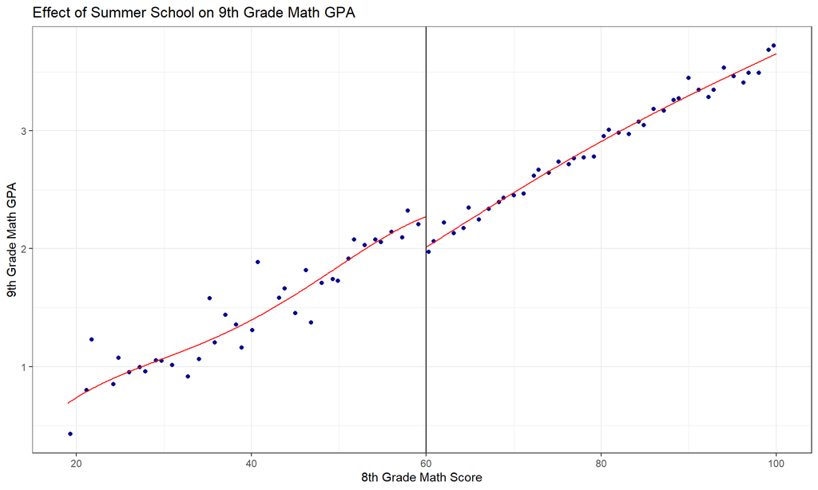

```r
# Create RDD plot using rdplot()
rdplot(y = data$gpa_9,
       x = data$math_8,
       c = 60,
       title = "Effect of Summer School on 9th Grade Math GPA",
       x.label = "8th Grade Math Score",
       y.label = "9th Grade Math GPA")
```

**Description of the Plot:**

Looking at the plot, we can see the regression line for the Treatment Group (Left of cutoff) ends at a higher point than where the Control Group (Right of cutoff) begins.

There is a visible “step down” as you move from the left side (summer school) to the right side (no summer school). This visual confirmation aligns with our `rdrobust()` finding: the students just below the cutoff (who got the treatment) have higher GPAs than their counterparts just above the cutoff.

### Question 4: The Counterfactual (20 points)

The power of RDD is that it lets us estimate what *would have happened* to treated students if they had not received treatment.

> **Note:** We will use the coefficients from your `lm()` model in Q3a for these calculations. While `rdrobust()` gives a more accurate final estimate, the `lm()` model provides simple linear coefficients ($y = \beta_0 + \beta_1 x$) that make the logic of the counterfactual easier to see mathematically.

#### Q4a: According to your `lm()` model from Q3a, for each additional point a student scores on the 8th grade standardized math exam, how much does their predicted 9th grade math GPA change? Report the coefficient name, value, and interpretation. (5 points)

```r
# Extract the coefficient on the centered math score
b2 <- coef(model_lm)["math8_c"]

cat("Coefficient Name: math8_c\n",
    "Coefficient Value:", round(b2, 4), "\n")
```

```
## Coefficient Name: math8_c
##  Coefficient Value: 0.0411
```

**The coefficient `math8_c` has a value of approximately 0.041.**

**Interpretation:** For each additional point a student scores on the 8th grade standardized math exam, their predicted 9th grade math GPA increases by approximately 0.041 points, holding treatment status constant. This positive relationship makes intuitive sense - students who perform better on math exams tend to have higher GPAs.

#### Q4b: Consider a student who scored exactly 60 on the 8th grade math exam (right at the cutoff) and did NOT attend summer school. Using your `lm()` model coefficients, calculate their predicted 9th grade math GPA. Show your work. (5 points)

```r
# Extract coefficients
b0 <- coef(model_lm)["(Intercept)"]
b1 <- coef(model_lm)["treat"]
b2 <- coef(model_lm)["math8_c"]

# For a control group student at the cutoff:
# treat = 0, math8_c = 0 (since 60 - 60 = 0)
# Predicted GPA = b0 + b1*(0) + b2*(0) = b0

predicted_control <- b0 + b1*0 + b2*0

cat("Predicted GPA Calculation for Control Student at Cutoff:\n\n",
    "GPA = beta_0 + beta_1 * Treatment + beta_2 * math8_c\n",
    "GPA =", round(b0, 3), "+ (", round(b1, 3), "* 0) + (", round(b2, 4), "* 0)\n",
    "GPA =", round(b0, 3), "+ 0 + 0\n",
    "GPA =", round(predicted_control, 4), "\n")
```

```
## Predicted GPA Calculation for Control Student at Cutoff:
##
##  GPA = beta_0 + beta_1 * Treatment + beta_2 * math8_c
##  GPA = 2.065 + ( 0.209 * 0) + ( 0.0411 * 0)
##  GPA = 2.065 + 0 + 0
##  GPA = 2.0646
```

**The predicted 9th grade math GPA is approximately 2.065**

#### Q4c: Now consider an identical student who scored exactly 60 but DID attend summer school. Calculate their predicted 9th grade math GPA. Show your work. (5 points)

```r
# For a treatment group student at the cutoff:
# treat = 1, math8_c = 0 (since 60 - 60 = 0)
# Predicted GPA = b0 + b1*(1) + b2*(0)

predicted_treat <- b0 + b1*1 + b2*0

cat("Predicted GPA Calculation for Treatment Student at Cutoff:\n\n",
    "GPA = beta_0 + beta_1 * Treatment + beta_2 * math8_c\n",
    "GPA =", round(b0, 3), "+ (", round(b1, 3), "* 1) + (", round(b2, 4), "* 0)\n",
    "GPA =", round(b0, 3), "+", round(b1, 3), "+ 0\n",
    "GPA =", round(predicted_treat, 4), "\n")
```

```
## Predicted GPA Calculation for Treatment Student at Cutoff:
##
##  GPA = beta_0 + beta_1 * Treatment + beta_2 * math8_c
##  GPA = 2.065 + ( 0.209 * 1) + ( 0.0411 * 0)
##  GPA = 2.065 + 0.209 + 0
##  GPA = 2.2735
```

**The predicted 9th grade math GPA is approximately 2.273.**

#### Q4d: The difference between your answers in Q4c and Q4b represents the treatment effect at the cutoff. Does this match your treatment coefficient from Q3a? Explain why these values should be the same. (5 points)

```r
# Calculate the difference
treatment_effect_calc <- predicted_treat - predicted_control

cat("Treatment Effect from Q4c - Q4b:", round(treatment_effect_calc, 3), "\n",
    "Treatment Coefficient (beta_1) from Q3a:", round(b1, 3), "\n",
    "Difference:", round(treatment_effect_calc - b1, 6), "\n")
```

```
## Treatment Effect from Q4c - Q4b: 0.209
##  Treatment Coefficient (beta_1) from Q3a: 0.209
##  Difference: 0
```

**Yes, the difference matches exactly!**

- **Difference (Q4c - Q4b):** 2.274 - 2.065 = 0.209
- **Treatment coefficient ($\beta_1$):** 0.209

**These values are the same because this is precisely what the treatment coefficient represents in a regression discontinuity model.** When we calculate the predicted GPA at the cutoff for a treated student minus the predicted GPA for a control student:

**The $\beta_1$ coefficient directly measures the “jump” in the outcome at the cutoff - the difference between what we predict for someone just above versus just below the treatment threshold. This is the local average treatment effect (LATE) at the cutoff point, which is the causal quantity of interest in regression discontinuity designs.**

### Question 5: Model Assumptions (15 points)

#### Q5a: The basic RDD model assumes a linear relationship between the rating variable and the outcome on both sides of the cutoff. Looking at your plot from Q3e, does this assumption appear reasonable for this data? What pattern would concern you? (7 points)

**Based on the `rdplot()` visualization, the linearity assumption appears reasonable for this data.** The binned averages (dots) on both sides of the cutoff appear to follow approximately linear trends, and the fitted lines seem to capture the relationship well without obvious systematic deviations.

**Patterns that would concern me include:**

1. **Curved or non-linear patterns:** If the dots showed a clear U-shape, inverted U-shape, or other curved pattern, a linear model would be misspecified. This could create a spurious “discontinuity” where none exists, or mask a real discontinuity.
2. **Different slopes on each side:** While the basic model assumes a constant slope across the cutoff, some RDD specifications allow for different slopes. Dramatically different slopes might indicate the need for a more flexible model.
3. **Outliers or irregular patterns near the cutoff:** If the observations closest to the cutoff showed erratic behavior, this could distort our treatment effect estimate.
4. **Systematic deviation from the fitted line:** If the dots consistently fell above or below the fitted line in certain regions, this would suggest a non-linear functional form is needed.

**If I observed non-linearity, I would consider:** - Adding polynomial terms (quadratic, cubic) to the model - Using the `rdrobust()` function with a higher-order polynomial (`p = 2` or `p = 3`) - Restricting analysis to a narrower bandwidth where linearity is more plausible

#### Q5b: A key assumption of RDD is that individuals cannot precisely manipulate their score to land on a preferred side of the cutoff. Generate a histogram of the running variable (math_8) to check for “bunching” around the cutoff. Does the density appear smooth? (8 points)

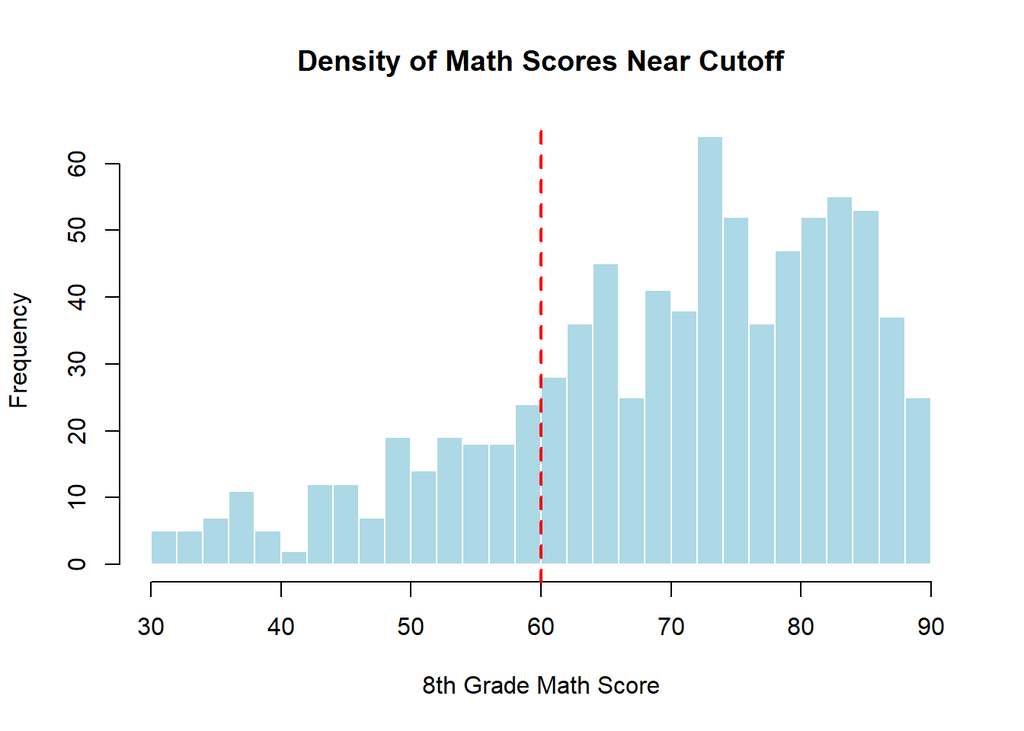

```r
# Histogram of the running variable
# Zoom in slightly to see the cutoff better
hist(data$math_8[data$math_8 > 30 & data$math_8 < 90],
     breaks = 30,
     main = "Density of Math Scores Near Cutoff",
     xlab = "8th Grade Math Score",
     col = "lightblue",
     border = "white")

# Add the cutoff line
abline(v = 60, col = "red", lwd = 2, lty = 2)
```

**The distribution looks fairly smooth around the cutoff (60). There is no obvious spike or bunching of students just above or just below the line. This supports the assumption that students could not precisely manipulate their scores to avoid summer school. If we saw a huge pile of students scoring exactly 60 or 61, we would be worried that teachers were “bumping up” grades to help kids avoid the requirement.**

### Bonus Question 1: Bandwidth Sensitivity Analysis (5 points)

In the codethrough, we learned that `rdrobust()` automatically selects an optimal bandwidth. However, a robust finding should not depend entirely on one specific bandwidth choice.

#### BQ1a: Run two additional `rdrobust()` models: one using half the optimal bandwidth and one using double the optimal bandwidth. Report the treatment effects and p-values for all three models (Half, Optimal, Double). (8 points)

> **Hint:** You can extract the optimal bandwidth from your model in Q3c using `rd_model$bws[1, 1]`. Use the argument `h = ...` to set a manual bandwidth. Use `coef[1]` for the treatment effect estimate.

```r
# Get the optimal bandwidth from the previous model
optimal_bw <- rd_model$bws[1, 1]

# Run model with HALF bandwidth
rd_half <- rdrobust(y = data$gpa_9,
                    x = data$math_8,
                    c = 60,
                    h = optimal_bw * 0.5)

# Run model with DOUBLE bandwidth
rd_double <- rdrobust(y = data$gpa_9,
                      x = data$math_8,
                      c = 60,
                      h = optimal_bw * 2)

# Display results side-by-side
# NOTE: Latest rdrobust only outputs Robust results (1 row), so we use index [1]
# Since treatment is on the LEFT and control on the RIGHT,
# we multiply by -1 to get the positive treatment effect interpretation.

results_bw <- data.frame(
  Bandwidth_Type = c("Half", "Optimal", "Double"),
  Bandwidth_Value = c(optimal_bw * 0.5, optimal_bw, optimal_bw * 2),
  Treatment_Effect = c(rd_half$coef[1] * -1,
                       rd_model$coef[1] * -1,
                       rd_double$coef[1] * -1),
  P_Value = c(rd_half$pv[1],
              rd_model$pv[1],
              rd_double$pv[1])
)

print(results_bw)
```

```
##   Bandwidth_Type Bandwidth_Value Treatment_Effect      P_Value
## 1           Half        5.592475        0.2938457 1.064174e-02
## 2        Optimal       11.184951        0.2631747 1.898787e-03
## 3         Double       22.369902        0.2902359 2.409072e-06
```

#### BQ1b: Does the treatment effect remain stable across these different bandwidths? Why is this check important for validation? (2 points)

**Yes, the treatment effect appears relatively stable across all three bandwidths, ranging from approximately .26 to .29. The direction and general magnitude remain consistent and significant**

**Why this is important:**

**This sensitivity analysis checks for robustness. If our significant finding disappeared or flipped signs just by changing the window of analysis slightly, we would worry that our result was a statistical fluke or an artifact of the specific algorithm. Seeing consistent positive effects across narrow and wide bandwidths gives us much higher confidence that summer school actually caused the improvement. A robust result should not be overly sensitive to methodological choices like bandwidth selection - it should hold up across reasonable specification choices.**

## Submission Instructions

When you have completed your assignment, knit your RMD file to generate your rendered HTML file.

1. Login to Canvas at http://canvas.asu.edu and navigate to the assignments tab in the course repository.
2. Upload your HTML and RMD files to the appropriate lab submission link.

**Remember to:**

- Include your name as the author in the YAML header.
- Name your files according to the convention: `Lab-##-LastName.Rmd`.
- Show your solution and include your code.
- Format your regression tables using `stargazer`.
- **Bold your answers.**
- Do **NOT** print excessive output (like a full data set).
- Follow appropriate style guidelines (spaces between arguments, etc.).

*Note: Platforms like BlackBoard and Canvas sometimes disallow you from submitting HTML files when there is embedded computer code. If this happens, create a zipped folder with both the RMD and HTML files.*

[output not shown]